# Demonstration of limmaDE2

JT Lovell

2016-11-04

### Overview

##### The R package limmaDE2 contains a set of functions designed to make running differential expression analyses in LIMMA more user friendly. There are several functions of this package:

- `pipeLIMMA` Run analyses of differnetial expression in LIMMA.
- `makeBinarySig` Find and count the number of significantly differentially expressed genes
- `pqHists` Plot the distribution of P and FDR-corrected P (Q) values
- `voom2PCA` Conduct principal component analyses on voom (or otherwise) normalized expression matrices
- `volcanoPlot` Generate log2 foldchange vs. P-value volcano plots
- `volcanoPair` Compare two sets of log2 fold changes, colored by p-values
- `pipeDESeq2` Runs an analysis of differential expression similar to that of pipeLIMMA, except through the DESeq2 package.

### 1. Installation

The limmaDE2 packages is not on CRAN and can only be installed from github. Make sure the `devtools` package is installed on your system. The limmaDE2 package also requires several other R packages to be installed. These packages have functions upon which limmaDE2 depends:

##### Essential Packages:

- `limma` contains all of the basic statistical elements that are called here.
- `qvalue` fdr-corrected p-values
- `edgeR` Differential expression package used for some transformations

##### Data for this vignette comes from:

- `SimSeq` permits simulation of RNA-seq data

##### Other useful packages:

- `plyr` summarize and manipulate lists and dataframes
- `vegan` some distance-based methods
- `Heatplus` heatmap plotting
- `topGO` gene ontology (GO) analysis
- `ggplot2` routines for complex plots
- `hexbin` methods to simplify data in plots

##### To install limmaDE2:

```r
library(devtools)
install_github("jtlovell/limmaDE2")
```

##### Load all packages that will be needed for the tutorial:

```r
library("limmaDE2")
library("ggplot2")
library("reshape2")
library("SimSeq")
library("DESeq2")
```

### 2. Importing data and checking

##### For limmaDE2 to work, two matrices are needed:

- `counts`: Raw transcript abundance counts
- `info`: Experimental design information These two matrices must match exactly, where each row in the `info` matrix corresponds to each column in `counts`. For best performance, the name of each gene should be stored in the rownames of the counts matrix.

```r
data(kidney) # from simseq
counts<-kidney$counts
counts<-counts[sample(1:nrow(counts),1000),]
info<-with(kidney,
           data.frame(id = paste(replic, treatment, sep = "_"),
                      rep=replic,
                      Treatment=ifelse(treatment == "Tumor","tumor","cntr"),
                      stringsAsFactors=F))
colnames(counts)<-info$id
```

##### Add in another category that gives us a factorial design

```r
group.a<-c("4619", "4712", "4863", "4865", "5452", "5453", "5454", "5455",
          "5456", "5457","5458", "5461", "5462", "5463", "5465", "5467",
          "5468", "5469", "5470", "5549","5552", "5580", "5641", "5672",
          "5689", "5701", "5703", "5706", "5989", "6088")
info$group<-ifelse(info$rep %in% group.a, "a","b")
with(info, table(group, Treatment))
```

```
##      Treatment
## group cntr tumor
##     a   30    30
##     b   42    42
```

```r
info$trt.grp<-with(info, paste(Treatment, group, sep="_"))
```

##### The top of the example experimental design dataset

```r
head(info)
```

```
##               id  rep Treatment group trt.grp
## 1 3358_Non-Tumor 3358      cntr     b  cntr_b
## 2     3358_Tumor 3358     tumor     b tumor_b
## 3 3387_Non-Tumor 3387      cntr     b  cntr_b
## 4     3387_Tumor 3387     tumor     b tumor_b
## 5 4619_Non-Tumor 4619      cntr     a  cntr_a
## 6     4619_Tumor 4619     tumor     a tumor_a
```

##### What the example counts dataset looks like

```r
counts[1:10,1:3]
```

```
##               3358_Non-Tumor 3358_Tumor 3387_Non-Tumor
## GSK3B|2932              2096       3973           2310
## TEC|7006                  88        246            125
## RTBDN|83546                0          0              0
## SNX13|23161             3139       4764           2798
## MAST1|22983                7          1              0
## TFAM|7019               1436       1697           1550
## UBXN10|127733            401       1581            260
## KRT14|3861                 0         28              2
## CINP|51550               993       1401           1104
## TACR1|6869                80        245             49
```

In all statistical analyses, it is important to set the levels of the experimental factors. This is esspecially true in linear modelling, such as limma, where levels are tested against the base level. Here, we set the “Non-Tumor” treatment and “a” group as the base.

```r
info$Treatment <- factor(info$Treatment,
                           levels = c("cntr", "tumor"))
info$group <- factor(info$group,
                           levels = c("a", "b"))
```

### 3. Basic analysis of differential expression

##### To test the plasticity (differential expression) of all genes between the tumor and control tissue:

```r
stats <- pipeLIMMA(counts = counts,
                   info = info,
                   block = NULL,
                   formula = "~ Treatment")
```

```
## calculating normalization factors ...
## running voom normalization correcting for quality weights ...
## fitting linear model ...
## processing statistics and calculating q-values ...
```

```r
lmStats<-stats$stats
voom<-stats$voom$E
```

`pipeLIMMA` returns three elements: `stats`, `voom` and `fstats`. These are the statistical output of the limma functions: `eBayes`, `voom` and `topTableF`. Inspect the top few rows and columns of each.

##### `stats`: eBayes linear model statistics

|  | gene | sigma | s2.post | Amean | Fstat | Fpvalue |
| --- | --- | --- | --- | --- | --- | --- |
| GSK3B\|2932 | GSK3B\|2932 | 0.8001060 | 0.6416126 | 10.281119 | 17.4070785 | 0.0000518 |
| TEC\|7006 | TEC\|7006 | 0.4726687 | 0.2330547 | 5.935553 | 47.5471968 | 0.0000000 |
| RTBDN\|83546 | RTBDN\|83546 | 1.2190479 | 1.4708851 | -1.752828 | 0.1332056 | 0.7156636 |
| SNX13\|23161 | SNX13\|23161 | 0.7140688 | 0.5138993 | 10.420350 | 23.7538159 | 0.0000028 |
| MAST1\|22983 | MAST1\|22983 | 1.2083085 | 1.4453294 | 1.163619 | 5.4418431 | 0.0210366 |
| TFAM\|7019 | TFAM\|7019 | 0.6495017 | 0.4275889 | 9.127099 | 166.6738831 | 0.0000000 |

##### `voom`: normalized expression matrix

|  | 3358_Non-Tumor | 3358_Tumor | 3387_Non-Tumor | 3387_Tumor | 4619_Non-Tumor | 4619_Tumor |
| --- | --- | --- | --- | --- | --- | --- |
| GSK3B\|2932 | 10.135067 | 10.202899 | 10.235435 | 10.402782 | 9.9837220 | 10.808928 |
| TEC\|7006 | 5.568906 | 6.192148 | 6.032989 | 5.679887 | 5.2827638 | 6.604529 |
| RTBDN\|83546 | -1.898700 | -2.753296 | -1.938555 | -2.690800 | -1.4587032 | -2.126790 |
| SNX13\|23161 | 10.717619 | 10.464813 | 10.511883 | 10.409041 | 10.4515648 | 12.185029 |
| MAST1\|22983 | 2.008191 | -1.168334 | -1.938555 | 1.557127 | 0.1262593 | 0.680565 |
| TFAM\|7019 | 9.589642 | 8.975900 | 9.659963 | 8.963388 | 9.6426160 | 9.449222 |

##### `fstats`: F-statistics for each factor in the model, in this case, just treatment

| gene | Treatment_F | Treatment_P.Value | Treatment_Q.Value |
| --- | --- | --- | --- |
| AATF\|26574 | 128.433398 | 0.0000000 | 0.0000000 |
| ABCB8\|11194 | 69.822932 | 0.0000000 | 0.0000000 |
| ABCC6P1\|653190 | 2.194034 | 0.1407181 | 0.1820415 |
| ABCC6P2\|730013 | 1.154329 | 0.2844313 | 0.3502849 |
| ACAD11\|84129 | 49.899739 | 0.0000000 | 0.0000000 |
| ACCN2\|41 | 96.479576 | 0.0000000 | 0.0000000 |

### 4. Differential expression using a blocking variable

##### Lets say that here, there is some sort of experimental blocking. In this case, we employ a routine in limma that calculates the `duplicateCorrelation` among blocks, then uses the blocking variable in the linear model fit.

```r
info$block <- rep(1:2,each=nrow(info)/2)
stats.block <- pipeLIMMA(counts = counts,
                   info = info,
                   block = info$block,
                   formula = "~ Treatment")
```

```
## calculating normalization factors ...
## running voom normalization correcting for quality weights ...
## calculating duplicate correlation among replicates ...
## fitting linear model ...
## processing statistics and calculating q-values ...
```

### 5. Differential expression in a factorial experiment

```r
stats.factorial <- pipeLIMMA(counts = counts,
                   info = info,
                   block = NULL,
                   formula = "~ Treatment + group + Treatment*group")
```

```
## calculating normalization factors ...
## running voom normalization correcting for quality weights ...
## fitting linear model ...
## processing statistics and calculating q-values ...
```

### 6. Calculating differential expression using specific contrasts

Sometimes, it may make more sense to use specific contrasts to test for differential expression. For example, let’s say we are interested in how the tumors and non-tumor tissues differ for each of the two groups.

##### First, we need to construct a design matrix.

```r
design <- with(info, model.matrix(~ 0 + trt.grp))
colnames(design)<-gsub("trt.grp","",colnames(design))
head(design)
```

```
##   cntr_a cntr_b tumor_a tumor_b
## 1      0      1       0       0
## 2      0      0       0       1
## 3      0      1       0       0
## 4      0      0       0       1
## 5      1      0       0       0
## 6      0      0       1       0
```

##### Then we construct a contrast matrix.

```r
contrast.matrix <- makeContrasts(
  tumor_a - cntr_a ,
  tumor_b - cntr_b,
  levels = design)
head(contrast.matrix)
```

```
##          Contrasts
## Levels    tumor_a - cntr_a tumor_b - cntr_b
##   cntr_a                -1                0
##   cntr_b                 0               -1
##   tumor_a                1                0
##   tumor_b                0                1
```

##### Finally, we fit the model with a contrast matrix as the design, overriding the formula argument.

```r
stats <- pipeLIMMA(counts = counts,
                   info = info,
                   block = NULL,
                   design = design,
                   contrast.matrix = contrast.matrix)
```

```
## calculating normalization factors ...
## running voom normalization correcting for quality weights ...
## fitting model to contrast matrix ...
## processing statistics and calculating q-values ...
```

```r
stats.contrasts <- stats$stats
```

### 6. Count and plot the number of significantly differentially expressed genes

The function `makeBinarySig` looks for a provided string (e.g. “Q.Value”) and outputs a matrix with whether or not those columns have values <= the provided alpha

```r
sigs <- makeBinarySig(stats.contrasts, what = "Qvalue", alpha = 0.05)
```

```
## ebayesQvalue_tumor_a...cntr_a    627
## ebayesQvalue_tumor_b...cntr_b    665
```

##### Make a venn diagram of number of differentially expressed genes among the experimental factors

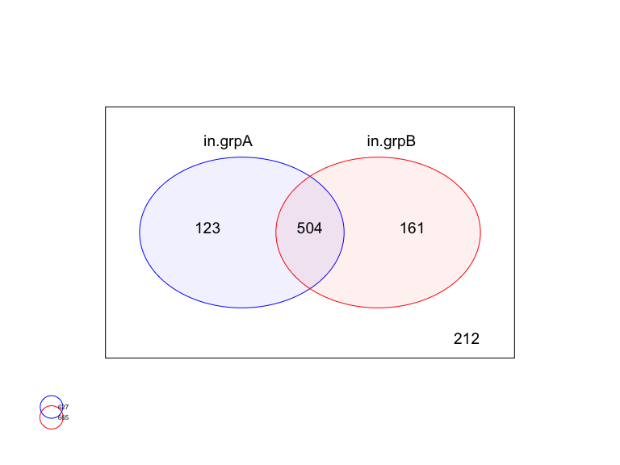

```r
counts2Venn(x=sigs, cols=c(1,2), names=c("in.grpA","in.grpB"),
   colors=c("blue","red"),type="limma", legx=-3.3,legy=-3)
```

##### Make a euler diagram of number of differentially expressed genes among the experimental factors

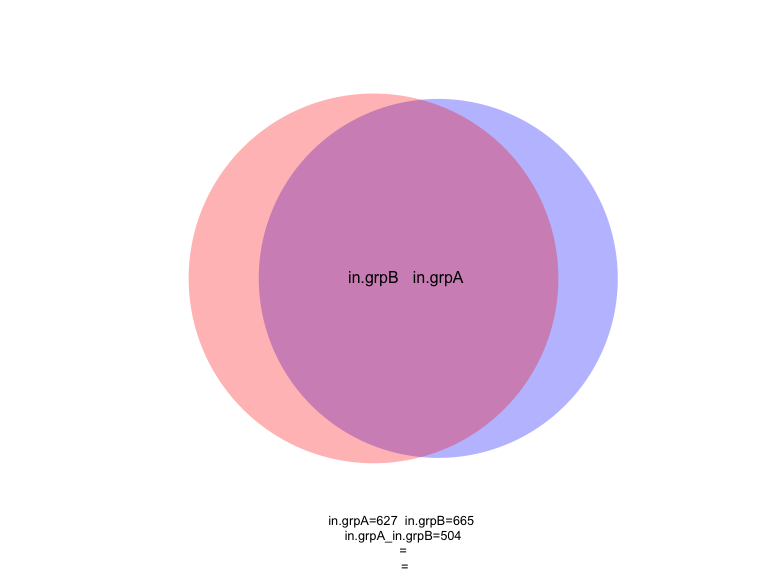

```r
counts2Venn(x=sigs, cols=c(1,2), names=c("in.grpA","in.grpB"),
   colors=c("blue","red"),type="Euler", legx=-3.3,legy=-3)
```

### 7. Make a volcano plot of the results

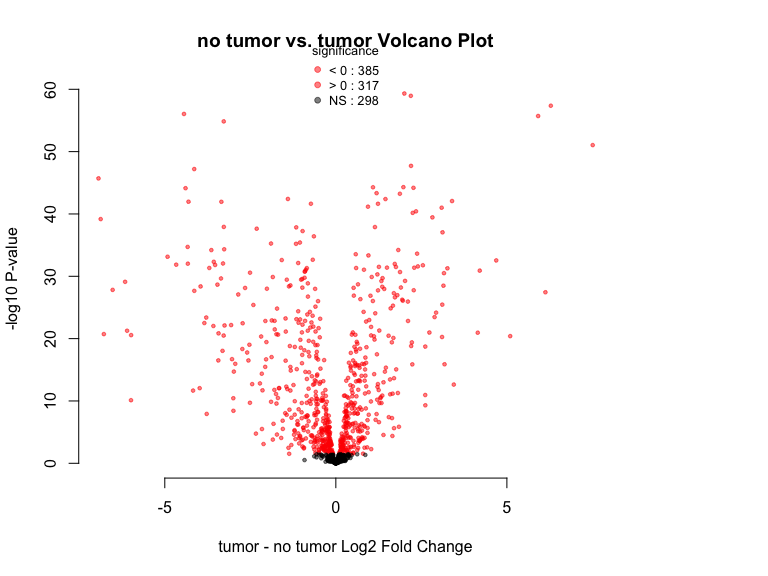

```
##       sig
## updown FALSE TRUE
##   down   130  385
##   up     168  317
```

```r
with(lmStats, volcanoPlot(pval = ebayesPvalue_Treatmenttumor,
                          lfc = Treatmenttumor_logFC,
                          sig = ebayesQvalue_Treatmenttumor,
                          main = "no tumor vs. tumor Volcano Plot",
                          xlab = "tumor - no tumor Log2 Fold Change",
                          bty = "n", legpos = "top", leginset = c(0,-.1)))
```

### 8. Using two contrasts, make a pairwise volcano plot

##### Custom colors

```r
sigs <- data.frame(makeBinarySig(stats.contrasts, what = "Qvalue", alpha = 0.05))
```

```
## ebayesQvalue_tumor_a...cntr_a    627
## ebayesQvalue_tumor_b...cntr_b    665
```

```r
names(sigs)<-c("sig.a","sig.b")
sigs$sign.a<-sign(stats.contrasts$tumor_a...cntr_a_logFC)
sigs$sign.b<-sign(stats.contrasts$tumor_b...cntr_b_logFC)

cols<-with(sigs, ifelse(sig.a + sig.b == 0,
                        "grey",
                        ifelse(sig.a + sig.b == 2 & sign.a*sign.b == 1,
                               "pink",
                               ifelse(sig.a + sig.b == 2 & sign.a*sign.b == -1,
                                      "cornflowerblue",
                                      ifelse(sig.a == 1, "darkblue", "darkred")))))
```

##### Make the plot

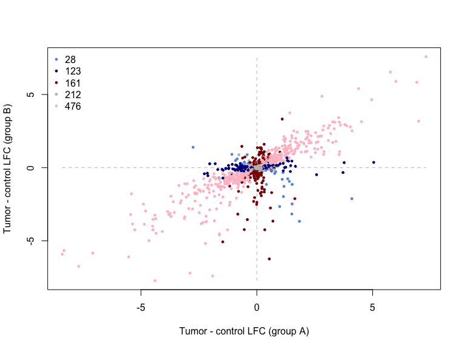

```
## pt.col
## cornflowerblue       darkblue        darkred           grey           pink
##             28            123            161            212            476
```

```r
with(stats.contrasts, volcanoPair(lfc1 = tumor_a...cntr_a_logFC,
                                  lfc2 = tumor_b...cntr_b_logFC,
                                  pt.col = cols, pt.pch = 19, pt.cex=.5,
                                  xlab = "Tumor - control LFC (group A)",
                                  ylab = "Tumor - control LFC (group B)"))
```

## Principal component analysis of gene expression

It is often a good idea to get an idea of how the individuals (libraries) are structured - how similar are they to eachother. Principal component analyses allow for this kind of inference.

```r
pca12 <- counts2PCA(counts=voom, info = info, ids = info$id, pcas2return = 6)
```

[figure not shown]

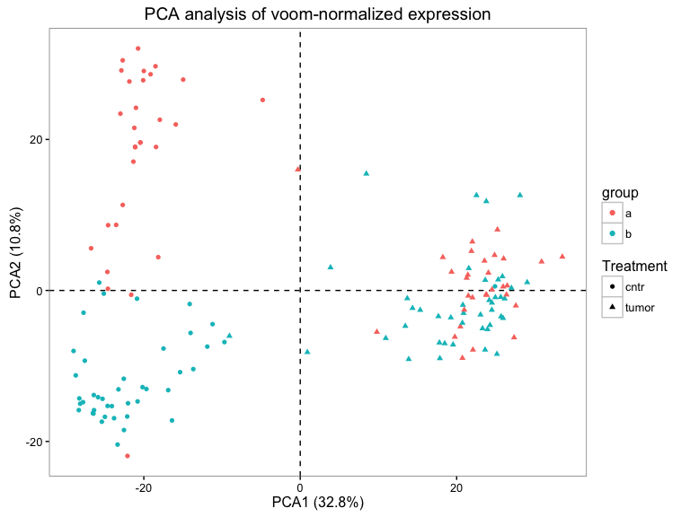

```r
pca12.var <- pca12[[2]]
pca12 <- pca12[[1]]
gcols <- c("darkblue", "blue", "gold", "green", "pink", "red")
ggplot(pca12, aes(x = PC1, y = PC2, col = group, shape = Treatment)) +
  geom_vline(xintercept = 0, lty = 2)+
  geom_hline(yintercept = 0, lty = 2)+
  geom_point() +
  theme_bw() +
  theme(panel.grid.major = element_blank(),
        panel.grid.minor = element_blank(),
        strip.background = element_blank()) +
  labs(x = paste("PCA1 (", pca12.var[1],"%)", sep = ""),
       y = paste("PCA2 (", pca12.var[2],"%)", sep = ""),
       title = "PCA analysis of voom-normalized expression")
```

For more information, visit lovelleeb.weebly.com/analytics